# Study 3a

## (1) Description of Data

The posted data for this study consists of 1 compiled, deidentified data file. This data file does not include data from an additional 284 respondents either because they did not complete the study, they completed the study more than once, or it was not possible to accurately match their separate survey sheets.

## (2) Descriptive Statistics

**Total *N*:** 541

**Sensitivity analysis:** This sample provided a statistical power of .80 to detect effects of *f*<sup>2</sup> >= 0.015.

**Percentage by gender:**

```
## Gender
## female   male   <NA>
##    310    226      5
```

*M*s and *SD*s:

```
##               n  mean   sd
## age         536 19.34 1.89
## rfa         485  0.22 0.91
## rfapro      490  5.45 0.99
## rfapre      493  5.23 1.07
## rfb         479  0.17 0.92
## rfbpro      485  5.34 1.04
## rfbpre      488  5.17 1.11
## rfq         509  0.49 1.01
## rfqpro      511  3.83 0.60
## rfqpre      510  3.33 0.86
## central.sa1 496  6.08 1.16
## central.sa2 493  5.60 1.39
## cent.dif    492  1.18 1.28
## rf.dif      468  0.83 0.78
```

**Alphas:**

- **Identity-specific motivation-A promotion:** 0.76
- **Identity-specific motivation-A prevention:** 0.7
- **Identity-specific motivation-B promotion:** 0.77
- **Identity-specific motivation-B prevention:** 0.71
- **RFQ promotion:** 0.68
- **RFQ prevention:** 0.75

## (3) Correlations

**Correlations:**

```
##             lower     r upper      p  df
## rfa-rfb      0.16  0.24  0.33 0.0000 466
## rfa-rfq     -0.15 -0.06  0.04 0.2301 466
## rfb-rfq     -0.08  0.02  0.11 0.7332 460
## rf.df-cnt.d  0.06  0.15  0.24 0.0013 465
```

## (4) Main Analyses

### Regressing on identity-specific motivation-A on identity-specific motivation-B, difference in centrality, and their interaction

**Main effects (Step 1)**

```
##
## Call:
## lm(formula = rfa ~ rfb_c + cent.dif_c)
##
## Residuals:
##     Min      1Q  Median      3Q     Max
## -3.3380 -0.4995 -0.0369  0.4852  3.5022
##
## Coefficients:
##             Estimate Std. Error t value Pr(>|t|)
## (Intercept)  0.21482    0.04122   5.212 2.82e-07 ***
## rfb_c        0.24650    0.04463   5.523 5.55e-08 ***
## cent.dif_c  -0.01474    0.03383  -0.436    0.663
## ---
## Signif. codes:  0 '***' 0.001 '**' 0.01 '*' 0.05 '.' 0.1 ' ' 1
##
## Residual standard error: 0.8904 on 464 degrees of freedom
##   (74 observations deleted due to missingness)
## Multiple R-squared:  0.06343,    Adjusted R-squared:  0.05939
## F-statistic: 15.71 on 2 and 464 DF,  p-value: 2.497e-07
```

**Step 1 CIs**

```
##             2.5 % 97.5 %
## (Intercept)  0.13   0.30
## rfb_c        0.16   0.33
## cent.dif_c  -0.08   0.05
```

**Interaction term added (Step 2)**

```
##
## Call:
## lm(formula = rfa ~ rfb_c * cent.dif_c)
##
## Residuals:
##     Min      1Q  Median      3Q     Max
## -3.1802 -0.5102 -0.0687  0.4593  3.4137
##
## Coefficients:
##                   Estimate Std. Error t value Pr(>|t|)
## (Intercept)       0.206623   0.041086   5.029 7.06e-07 ***
## rfb_c             0.250979   0.044387   5.654 2.74e-08 ***
## cent.dif_c       -0.007063   0.033753  -0.209   0.8343
## rfb_c:cent.dif_c -0.079351   0.030511  -2.601   0.0096 **
## ---
## Signif. codes:  0 '***' 0.001 '**' 0.01 '*' 0.05 '.' 0.1 ' ' 1
##
## Residual standard error: 0.8849 on 463 degrees of freedom
##   (74 observations deleted due to missingness)
## Multiple R-squared:  0.07691,    Adjusted R-squared:  0.07093
## F-statistic: 12.86 on 3 and 463 DF,  p-value: 4.394e-08
```

**Step 2 CIs**

```
##                  2.5 % 97.5 %
## (Intercept)       0.13   0.29
## rfb_c             0.16   0.34
## cent.dif_c       -0.07   0.06
## rfb_c:cent.dif_c -0.14  -0.02
```

*f*<sup>2</sup> value (effect size) for interaction term: 0.015

**Simple slopes**

```
##
## ** Estimated points of rfa  **
##
##                         Low rfb_c (-1 SD) High rfb_c (+1 SD)
## Low cent.dif_c (-1 SD)            -0.1091             0.5421
## High cent.dif_c (+1 SD)            0.0534             0.3439
##
##
##
## ** Simple Slopes analysis ( df= 463 ) **
##
##                         simple slope standard error t-value p.value
## Low cent.dif_c (-1 SD)        0.3508         0.0598    5.87  <2e-16 ***
## High cent.dif_c (+1 SD)       0.1564         0.0563    2.78  0.0057 **
## ---
## Signif. codes:  0 '***' 0.001 '**' 0.01 '*' 0.05 '.' 0.1 ' ' 1
##
##
##
## ** Bauer & Curran 95% CI **
##
##            lower CI upper CI
## cent.dif_c   1.5774   12.916
```

**CIs among those with high identity incompatibility:** 0.23, 0.47

**CIs among those with low identity incompatibility:** 0.05, 0.27

### Regressing on identity-specific motivation-B on identity-specific motivation-A, difference in centrality, and their interaction

**Main effects (Step 1)**

```
##
## Call:
## lm(formula = rfb ~ rfa_c + cent.dif_c)
##
## Residuals:
##     Min      1Q  Median      3Q     Max
## -2.5050 -0.5679 -0.1308  0.4326  3.3078
##
## Coefficients:
##             Estimate Std. Error t value Pr(>|t|)
## (Intercept)  0.17369    0.04153   4.182 3.46e-05 ***
## rfa_c        0.25028    0.04531   5.523 5.55e-08 ***
## cent.dif_c  -0.06293    0.03397  -1.852   0.0646 .
## ---
## Signif. codes:  0 '***' 0.001 '**' 0.01 '*' 0.05 '.' 0.1 ' ' 1
##
## Residual standard error: 0.8972 on 464 degrees of freedom
##   (74 observations deleted due to missingness)
## Multiple R-squared:  0.06992,    Adjusted R-squared:  0.06591
## F-statistic: 17.44 on 2 and 464 DF,  p-value: 4.969e-08
```

**Step 1 CIs**

```
##             2.5 % 97.5 %
## (Intercept)  0.09   0.26
## rfa_c        0.16   0.34
## cent.dif_c  -0.13   0.00
```

**Interaction term added (Step 2)**

```
##
## Call:
## lm(formula = rfb ~ rfa_c * cent.dif_c)
##
## Residuals:
##     Min      1Q  Median      3Q     Max
## -2.5474 -0.5547 -0.1212  0.4376  3.4417
##
## Coefficients:
##                  Estimate Std. Error t value Pr(>|t|)
## (Intercept)       0.16957    0.04131   4.105 4.78e-05 ***
## rfa_c             0.25000    0.04504   5.551 4.79e-08 ***
## cent.dif_c       -0.05680    0.03385  -1.678  0.09398 .
## rfa_c:cent.dif_c -0.08961    0.03461  -2.589  0.00993 **
## ---
## Signif. codes:  0 '***' 0.001 '**' 0.01 '*' 0.05 '.' 0.1 ' ' 1
##
## Residual standard error: 0.8918 on 463 degrees of freedom
##   (74 observations deleted due to missingness)
## Multiple R-squared:  0.0832, Adjusted R-squared:  0.07726
## F-statistic: 14.01 on 3 and 463 DF,  p-value: 9.382e-09
```

**Step 2 CIs**

```
##                  2.5 % 97.5 %
## (Intercept)       0.09   0.25
## rfa_c             0.16   0.34
## cent.dif_c       -0.12   0.01
## rfa_c:cent.dif_c -0.16  -0.02
```

*f*<sup>2</sup> value (effect size) for interaction term: 0.014

**Simple slopes**

```
##
## ** Estimated points of rfb  **
##
##                         Low rfa_c (-1 SD) High rfa_c (+1 SD)
## Low cent.dif_c (-1 SD)            -0.0922             0.5737
## High cent.dif_c (+1 SD)           -0.0297             0.2333
##
##
##
## ** Simple Slopes analysis ( df= 463 ) **
##
##                         simple slope standard error t-value p.value
## Low cent.dif_c (-1 SD)        0.3627         0.0626    5.80  <2e-16 ***
## High cent.dif_c (+1 SD)       0.1432         0.0611    2.34    0.02 *
## ---
## Signif. codes:  0 '***' 0.001 '**' 0.01 '*' 0.05 '.' 0.1 ' ' 1
##
##
##
## ** Bauer & Curran 95% CI **
##
##            lower CI upper CI
## cent.dif_c    1.362   11.716
```

**CIs among those with high identity incompatibility:** 0.24, 0.49

**CIs among those with low identity incompatibility:** 0.02, 0.26

## (5) Figure

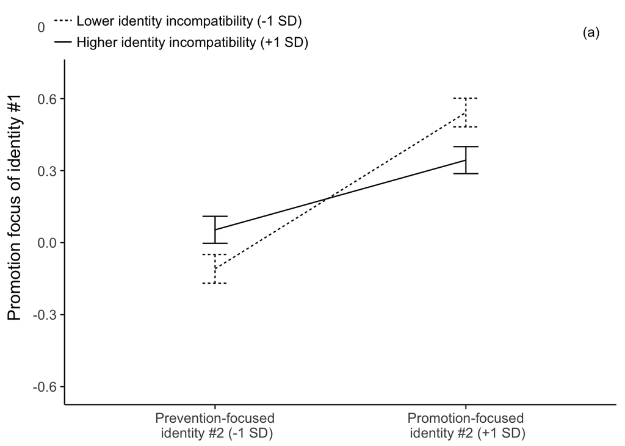